# Project 2: Linear Regression

Anqi Wu

Fall 2023

## Basic Dataset Information

The goal of this project is to use linear regression to model flight delays as a function of other variables.

```
## [1] 34314    21
```

```
##       YEAR          MONTH     DAY_OF_MONTH      DEP_TIME      DEP_DELAY
##  Min.   :2016   Min.   :12   Min.   : 1.00   Min.   :   1   Min.   : -23.00
##  1st Qu.:2016   1st Qu.:12   1st Qu.: 8.00   1st Qu.: 958   1st Qu.:  -4.00
##  Median :2016   Median :12   Median :16.00   Median :1356   Median :  -1.00
##  Mean   :2016   Mean   :12   Mean   :15.88   Mean   :1387   Mean   :  15.57
##  3rd Qu.:2016   3rd Qu.:12   3rd Qu.:23.00   3rd Qu.:1822   3rd Qu.:  13.00
##  Max.   :2016   Max.   :12   Max.   :31.00   Max.   :2400   Max.   :1167.00
##                                              NA's   :881    NA's   :881
##     TAXI_OUT       WHEELS_OFF     WHEELS_ON       TAXI_IN           ARR_TIME
##  Min.   :  2.0   Min.   :   1   Min.   :   1   Min.   :  1.000   Min.   :   1
##  1st Qu.: 13.0   1st Qu.:1013   1st Qu.:1149   1st Qu.:  4.000   1st Qu.:1152
##  Median : 17.0   Median :1418   Median :1556   Median :  6.000   Median :1559
##  Mean   : 18.6   Mean   :1416   Mean   :1545   Mean   :  7.334   Mean   :1547
##  3rd Qu.: 21.0   3rd Qu.:1837   3rd Qu.:2004   3rd Qu.:  8.000   3rd Qu.:2007
##  Max.   :139.0   Max.   :2400   Max.   :2400   Max.   :150.000   Max.   :2400
##  NA's   :900     NA's   :900    NA's   :935    NA's   :935       NA's   :935
##    ARR_DELAY         CANCELLED          DIVERTED        ACTUAL_ELAPSED_TIME
##  Min.   : -52.00   Min.   :0.00000   Min.   :0.000000   Min.   : 29.0
##  1st Qu.: -11.00   1st Qu.:0.00000   1st Qu.:0.000000   1st Qu.: 98.0
##  Median :  -2.00   Median :0.00000   Median :0.000000   Median :133.0
##  Mean   :  12.23   Mean   :0.02634   Mean   :0.003002   Mean   :146.4
##  3rd Qu.:  15.00   3rd Qu.:0.00000   3rd Qu.:0.000000   3rd Qu.:180.0
##  Max.   :1189.00   Max.   :1.00000   Max.   :1.000000   Max.   :615.0
##  NA's   :1007                                           NA's   :1007
##     DISTANCE      CARRIER_DELAY      WEATHER_DELAY       NAS_DELAY
##  Min.   :  67.0   Min.   :   0.000   Min.   :  0.000   Min.   :  0.00
##  1st Qu.: 501.0   1st Qu.:   0.000   1st Qu.:  0.000   1st Qu.:  0.00
##  Median : 802.0   Median :   0.000   Median :  0.000   Median :  0.00
##  Mean   : 865.6   Mean   :   5.717   Mean   :  1.489   Mean   :  3.31
##  3rd Qu.:1182.0   3rd Qu.:   0.000   3rd Qu.:  0.000   3rd Qu.:  0.00
##  Max.   :4243.0   Max.   :1162.000   Max.   :935.000   Max.   :755.00
##
##  SECURITY_DELAY      LATE_AIRCRAFT_DELAY    X
##  Min.   : 0.000000   Min.   :  0.00      Mode:logical
##  1st Qu.: 0.000000   1st Qu.:  0.00      NA's:34314
##  Median : 0.000000   Median :  0.00
##  Mean   : 0.004197   Mean   :  6.09
##  3rd Qu.: 0.000000   3rd Qu.:  0.00
##  Max.   :30.000000   Max.   :582.00
##
```

By observing the data frame dimension and summary, we can see that our dataset is comprising 21 columns and 34,314 rows. Among these 21 columns, the ‘YEAR’ and ‘MONTH’ columns exhibit constant values, and the ‘X’ column is filled with missing values (NAs), which are uninformative. DAY_OF_MONTH is also not very useful as flight delay is more likely to be directly related to the time of day, day of the week, or season, rather than the specific year, month, or day of the month.

Furthermore, the ‘CANCELLED’ and ‘DIVERTED’ columns contain binary values (0s and 1s), indicating they are categorical columns, and they should be removed because it might be more beneficial to focus on regularly operated flights for the predict flight delay analysis. The ‘CARRIER_DELAY,’ ‘WEATHER_DELAY,’ ‘NAS_DELAY,’ ‘SECURITY_DELAY,’ and ‘LATE_AIRCRAFT_DELAY’ columns predominantly consist of 0s, suggesting that only a minority of airline instances experience delays due to these specific reasons.

## Data Preprocessing

### Removing Columns

The columns that I am considering removing are YEAR, MONTH,DAY_OF_MONTH, CANCELLED, DIVERTED and X.

```
## [1] 34314    15
```

We removed 6 columns, so there are 15 columns left.

### Removing Rows by NaNs

```r
w <- complete.cases(df)
df <- df[w,]
dim(df)
```

```
## [1] 33307    15
```

After removing 1007 rows of missing data by complete.cases(), we have have 33307 rows of data left.

### Removing Outliers

#### Log Transformation

```r
#Log transform the response variable to reduce skewness
#install.packages("moments")
library(moments)
variables_to_analyze <- c("DEP_TIME", "DEP_DELAY", "TAXI_OUT", "WHEELS_OFF",
                           "WHEELS_ON", "TAXI_IN", "ARR_TIME", "ARR_DELAY",
                           "ACTUAL_ELAPSED_TIME", "DISTANCE", "CARRIER_DELAY",
                           "WEATHER_DELAY", "NAS_DELAY", "SECURITY_DELAY",
                           "LATE_AIRCRAFT_DELAY")

for (var in variables_to_analyze) {
  #hist(df[[var]], main=var, xlab=var)
  cat(var, ':', skewness(df[[var]]), '\n')
}
```

```
## DEP_TIME : -0.02586633
## DEP_DELAY : 7.434649
## TAXI_OUT : 2.995604
## WHEELS_OFF : -0.05383911
## WHEELS_ON : -0.5251982
## TAXI_IN : 6.437188
## ARR_TIME : -0.5727613
## ARR_DELAY : 6.744726
## ACTUAL_ELAPSED_TIME : 1.331744
## DISTANCE : 1.269109
## CARRIER_DELAY : 16.56514
## WEATHER_DELAY : 26.48305
## NAS_DELAY : 14.17132
## SECURITY_DELAY : 75.35808
## LATE_AIRCRAFT_DELAY : 7.150761
```

As we can see from the skewness score: DEP_DELAY,TAXI_OUT,TAXI_IN,ARR_DELAY,CARRIER_DELAY,WEATHER_DELAY,NAS_DELAY,SECURITY_DELAY, and LATE_AIRCRAFT_DELAY are highly skewed; WHEELS_ON, ARR_TIME, ACTUAL_ELAPSED_TIME, and DISTANCE are slightly skewed; the rest of the variable are nearly symmetric.

```r
df1<-df
variables_to_transform <- c( "TAXI_OUT", "TAXI_IN","CARRIER_DELAY",
                           "WEATHER_DELAY", "NAS_DELAY", "SECURITY_DELAY",
                           "LATE_AIRCRAFT_DELAY")
for (var in variables_to_transform) {
  df1[[var]] <- log(df[[var]]+1)
  #hist(df1[[var]], main=var, xlab=var)
  cat(var, ':', skewness(df1[[var]]), '\n')
}
```

```
## TAXI_OUT : 0.8001187
## TAXI_IN : 1.076797
## CARRIER_DELAY : 2.530232
## WEATHER_DELAY : 6.058813
## NAS_DELAY : 2.533394
## SECURITY_DELAY : 62.67063
## LATE_AIRCRAFT_DELAY : 2.811126
```

```r
df1$DEP_DELAY <- log(df$DEP_DELAY + 53)
#hist(df1$DEP_DELAY, main="DEP_DELAY", xlab="DEP_DELAY")
cat("DEP_DELAY:", skewness(df1$DEP_DELAY, na.rm = TRUE), '\n')
```

```
## DEP_DELAY: 2.293156
```

By comparing the skewness scores, we notice that after log transformed the highly skewed variable, we reduced their skewness.

#### Remove outliers by zscore

```r
var <- names(df1)

df2 <- df1 %>%
  mutate(across(all_of(var), list(z = ~ (scale(.) %>% as.numeric)), .names = "{col}_z")) %>%
  filter(if_all(ends_with("_z"), ~abs(.) < 3)) %>%
  select(-ends_with("_z"))
summary(df2)
```

```
##     DEP_TIME      DEP_DELAY        TAXI_OUT       WHEELS_OFF     WHEELS_ON
##  Min.   :   3   Min.   :3.401   Min.   :1.946   Min.   :   6   Min.   :   1
##  1st Qu.: 934   1st Qu.:3.892   1st Qu.:2.639   1st Qu.: 953   1st Qu.:1146
##  Median :1342   Median :3.932   Median :2.833   Median :1400   Median :1549
##  Mean   :1361   Mean   :4.011   Mean   :2.880   Mean   :1392   Mean   :1548
##  3rd Qu.:1753   3rd Qu.:4.078   3rd Qu.:3.091   3rd Qu.:1812   3rd Qu.:1955
##  Max.   :2359   Max.   :5.075   Max.   :3.951   Max.   :2359   Max.   :2400
##     TAXI_IN          ARR_TIME      ARR_DELAY       ACTUAL_ELAPSED_TIME
##  Min.   :0.6931   Min.   :   1   Min.   :-52.000   Min.   : 31.0
##  1st Qu.:1.6094   1st Qu.:1150   1st Qu.:-13.000   1st Qu.: 97.0
##  Median :1.9459   Median :1552   Median : -4.000   Median :130.0
##  Mean   :1.9524   Mean   :1552   Mean   : -1.213   Mean   :141.1
##  3rd Qu.:2.1972   3rd Qu.:1958   3rd Qu.:  7.000   3rd Qu.:175.0
##  Max.   :3.3673   Max.   :2400   Max.   :103.000   Max.   :328.0
##     DISTANCE      CARRIER_DELAY   WEATHER_DELAY        NAS_DELAY
##  Min.   :  67.0   Min.   :0.000   Min.   :0.000000   Min.   :0.0000
##  1st Qu.: 522.0   1st Qu.:0.000   1st Qu.:0.000000   1st Qu.:0.0000
##  Median : 802.0   Median :0.000   Median :0.000000   Median :0.0000
##  Mean   : 844.5   Mean   :0.268   Mean   :0.001461   Mean   :0.2085
##  3rd Qu.:1171.0   3rd Qu.:0.000   3rd Qu.:0.000000   3rd Qu.:0.0000
##  Max.   :2165.0   Max.   :3.932   Max.   :1.791759   Max.   :3.4657
##  SECURITY_DELAY LATE_AIRCRAFT_DELAY
##  Min.   :0      Min.   :0.0000
##  1st Qu.:0      1st Qu.:0.0000
##  Median :0      Median :0.0000
##  Mean   :0      Mean   :0.1817
##  3rd Qu.:0      3rd Qu.:0.0000
##  Max.   :0      Max.   :3.9120
```

We eliminated 4,410 outliers using the z-score method, leaving 28,897 data points for further analysis. After outlier removal, the SECURITY_DELAY column appears to consist solely of zeros. This observation suggests that security delays are exceedingly rare and infrequent within our dataset. Given this lack of variability, the SECURITY_DELAY column may not provide substantial insight for our analysis of delays. Thus, we can exclude this column from our dataset, and we will have 14 columns left.

### Correlation Plot

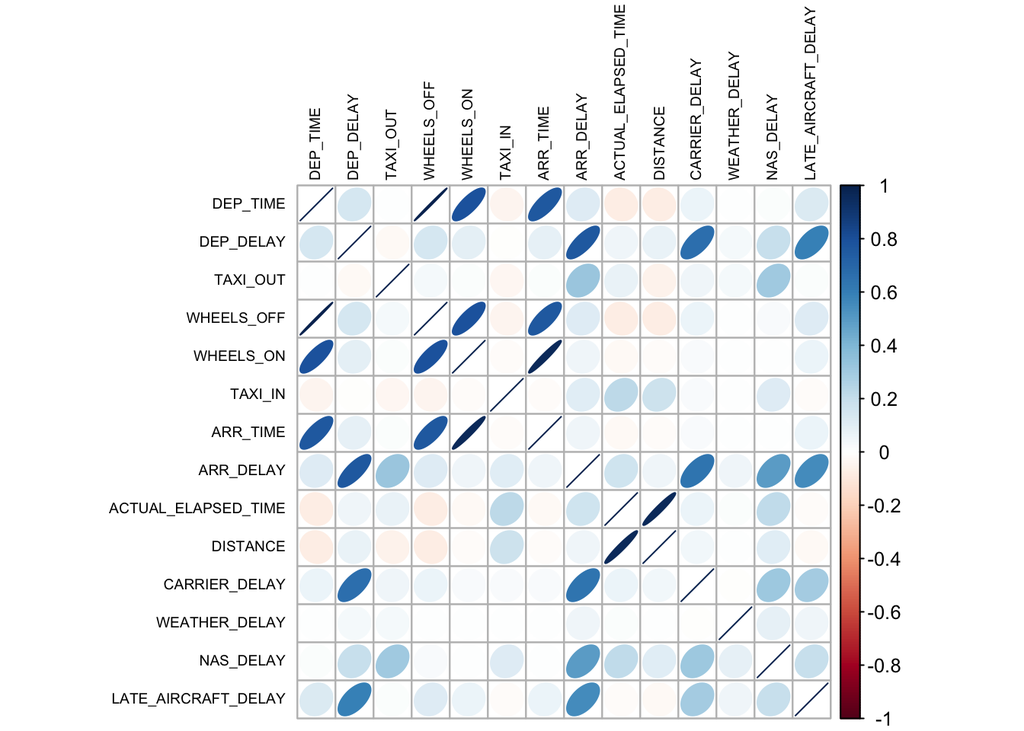

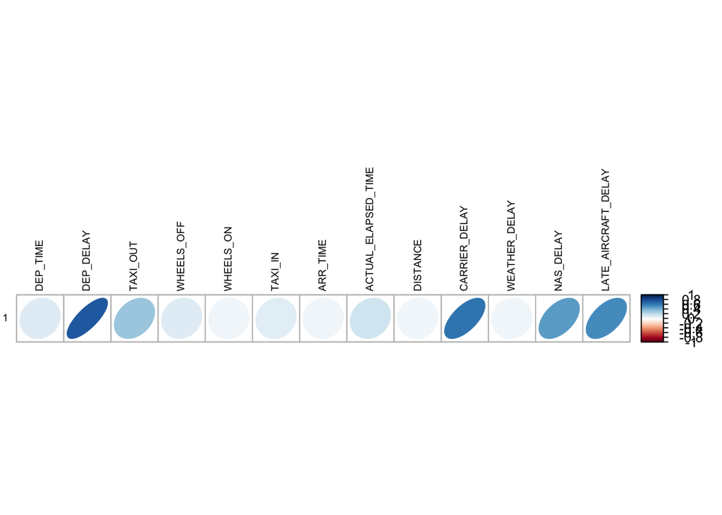

By observing the correlation plot, we can see there are 15 strongly correlated pairs of variables: (DEP_TIME,WHEELS_ON),(DEP_TIME, WHEEL_OFF),(DEP_TIME,ARR_TIME),(DEP_DELAY,ARR_DELAY),(DEP_DELAY,CARRIER_DELAY),(DEP_DELAY,LATE_AIRCRAFT_DELAY),(WHEELS_OFF,WHEELS_ON),(WHEELS_OFF,ARR_TIME),(WHEELS_ON,ARR_TIME),(TAXI_OUT,NAS_DELAY),(ARR_DELAY,CARRIER_DELAY),(ARR_DELAY,NAS_DELAY), (ARR_DELAY, LATE_AIRCRAFT_DELAY),(ARR_DELAY, TAXI_OUT), (ACTUAL_ELAPSED_TIME,DISTANCE).

Within these 15 pair, there are 5 variables that are correlated with the response variable ARR_DELAY: DEP_DELAY, TAXI_OUT, CARRIER_DELAY, NAS_DELAY, and LATE_AIRCRAFT_DELAY.

### Split Data to Training set and Test set

```r
set.seed(777)

splitIndex <- createDataPartition(df3$ARR_DELAY, p = 0.7, list = FALSE)
trainSet <- df3[splitIndex, ]
testSet <- df3[-splitIndex, ]
```

To ensure consistency and reproducibility in our analysis, I initialized the random number generator with a specific seed value. Following this, I partitioned the dataset, allocating 70% of the data for training purposes and reserving the remaining 30% for testing. This split facilitates model training while also allowing for robust evaluation and validation of the model’s performance on unseen data.

My training data has 20229 rows while test set has 8668 rows.

### Linear Regression on Full dataset

```r
model <- lm(ARR_DELAY ~ ., data = df3)
summary(model)
```

```
##
## Call:
## lm(formula = ARR_DELAY ~ ., data = df3)
##
## Residuals:
##     Min      1Q  Median      3Q     Max
## -34.160  -4.056   0.196   4.388  30.006
##
## Coefficients:
##                       Estimate Std. Error  t value Pr(>|t|)
## (Intercept)         -2.309e+02  1.290e+00 -179.024  < 2e-16 ***
## DEP_TIME             5.983e-04  1.149e-03    0.521  0.60242
## DEP_DELAY            4.793e+01  3.054e-01  156.935  < 2e-16 ***
## TAXI_OUT             8.166e+00  1.447e-01   56.449  < 2e-16 ***
## WHEELS_OFF          -1.093e-03  1.155e-03   -0.946  0.34399
## WHEELS_ON            1.282e-03  3.243e-04    3.951 7.81e-05 ***
## TAXI_IN              1.787e+00  9.554e-02   18.701  < 2e-16 ***
## ARR_TIME            -8.016e-04  3.001e-04   -2.671  0.00756 **
## ACTUAL_ELAPSED_TIME  2.655e-01  2.796e-03   94.979  < 2e-16 ***
## DISTANCE            -3.434e-02  3.670e-04  -93.563  < 2e-16 ***
## CARRIER_DELAY        2.636e+00  6.343e-02   41.553  < 2e-16 ***
## WEATHER_DELAY       -6.012e-01  8.236e-01   -0.730  0.46545
## NAS_DELAY            3.483e+00  6.335e-02   54.981  < 2e-16 ***
## LATE_AIRCRAFT_DELAY  2.878e+00  6.759e-02   42.585  < 2e-16 ***
## ---
## Signif. codes:  0 '***' 0.001 '**' 0.01 '*' 0.05 '.' 0.1 ' ' 1
##
## Residual standard error: 6.496 on 28883 degrees of freedom
## Multiple R-squared:  0.8492, Adjusted R-squared:  0.8492
## F-statistic: 1.251e+04 on 13 and 28883 DF,  p-value: < 2.2e-16
```

Upon examining the summary of the linear regression model, it is evident that the variables DEP_DELAY, TAXI_OUT, TAXI_IN, ACTUAL_ELAPSED_TIME, DISTANCE, CARRIER_DELAY, NAS_DELAY, and LATE_AIRCRAFT_DELAY exhibit extremely small p-values, coupled with relatively large absolute values of their coefficients. This suggests a statistically significant relationship with ARR_DELAY. While some of these relationships align with our observations from the correlation plot, indicating a strong correlation with ARR_DELAY, others were not as apparent in the initial analysis.

As the Multiple R-squared and Adjusted R-squared are pretty close to 1, this indicates that our model has a good fit.

### predicted response vs. observed response

```r
#perform linear regression on trainSet
model1 <- lm(ARR_DELAY ~ ., data = trainSet)
#model summary
summary(model1)
```

```
##
## Call:
## lm(formula = ARR_DELAY ~ ., data = trainSet)
##
## Residuals:
##     Min      1Q  Median      3Q     Max
## -34.336  -4.037   0.190   4.404  29.778
##
## Coefficients:
##                       Estimate Std. Error  t value Pr(>|t|)
## (Intercept)         -2.311e+02  1.537e+00 -150.358  < 2e-16 ***
## DEP_TIME             2.433e-04  1.338e-03    0.182 0.855690
## DEP_DELAY            4.785e+01  3.644e-01  131.299  < 2e-16 ***
## TAXI_OUT             8.242e+00  1.719e-01   47.943  < 2e-16 ***
## WHEELS_OFF          -6.178e-04  1.346e-03   -0.459 0.646278
## WHEELS_ON            1.465e-03  3.790e-04    3.866 0.000111 ***
## TAXI_IN              1.831e+00  1.138e-01   16.098  < 2e-16 ***
## ARR_TIME            -1.041e-03  3.488e-04   -2.986 0.002834 **
## ACTUAL_ELAPSED_TIME  2.657e-01  3.340e-03   79.551  < 2e-16 ***
## DISTANCE            -3.423e-02  4.381e-04  -78.132  < 2e-16 ***
## CARRIER_DELAY        2.680e+00  7.569e-02   35.404  < 2e-16 ***
## WEATHER_DELAY       -8.437e-01  1.051e+00   -0.803 0.421986
## NAS_DELAY            3.401e+00  7.598e-02   44.765  < 2e-16 ***
## LATE_AIRCRAFT_DELAY  2.886e+00  8.096e-02   35.648  < 2e-16 ***
## ---
## Signif. codes:  0 '***' 0.001 '**' 0.01 '*' 0.05 '.' 0.1 ' ' 1
##
## Residual standard error: 6.484 on 20215 degrees of freedom
## Multiple R-squared:  0.8489, Adjusted R-squared:  0.8488
## F-statistic:  8733 on 13 and 20215 DF,  p-value: < 2.2e-16
```

```r
#calculate predictions on the test set
predicted_values <- predict(model1, newdata = testSet)
#calculate mean square error
mse <- mean((testSet$ARR_DELAY - predicted_values)^2)
print(paste("The mse is:", mse))
```

```
## [1] "The mse is: 42.6127712623842"
```

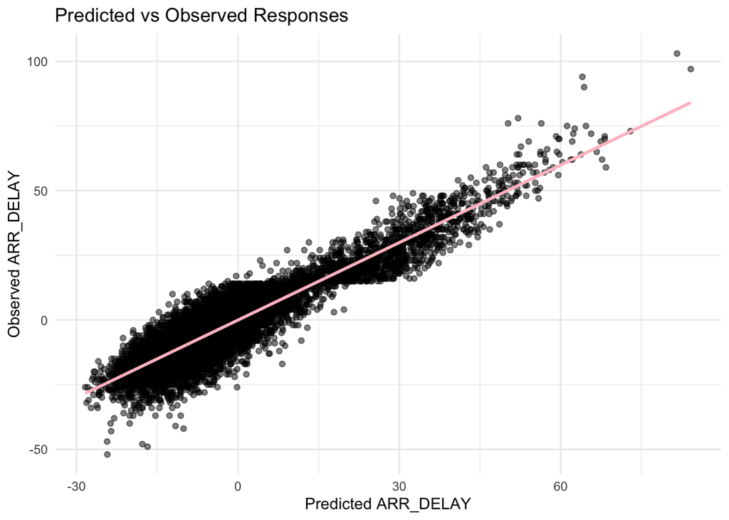

```r
#diagnostics plot
ggplot(data = testSet, aes(x = predicted_values, y = ARR_DELAY)) +
  geom_point(alpha = 0.5) +
  geom_smooth(method = "lm", se = FALSE, color = "pink") +
  labs(title = "Predicted vs Observed Responses",
       x = "Predicted ARR_DELAY",
       y = "Observed ARR_DELAY") +
  theme_minimal()
```

The adjusted R-squared of the linear model of the trainSet is 0.8488, which is pretty high and close to 1, so it the linear model is useful in this case.

### Residuals

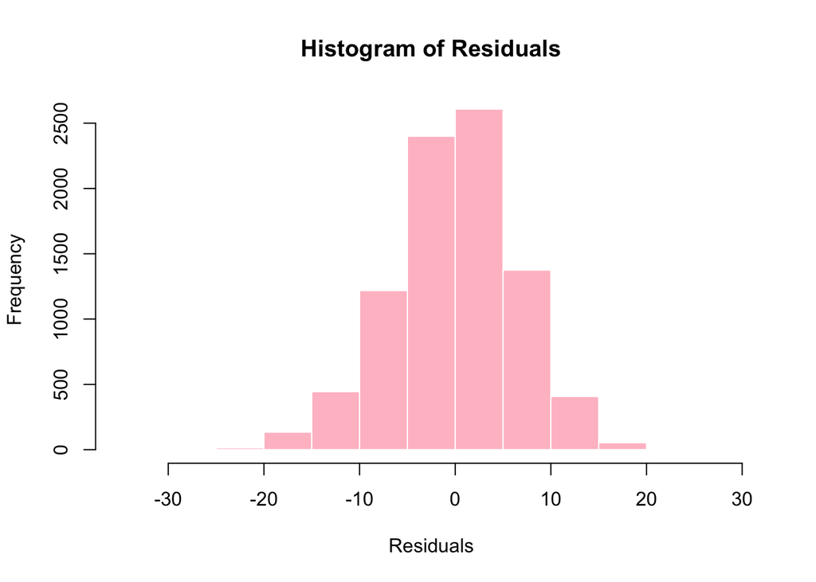

Since the residuals of the fit are normally distributed, we do not need to transform the response variable.

### Cariance-Inflation factors

```r
library(car)
# compute VIF
vif_values <- vif(model1)
print(vif_values)
```

```
##            DEP_TIME           DEP_DELAY            TAXI_OUT          WHEELS_OFF
##          187.809092            2.731684            1.457697          189.694584
##           WHEELS_ON             TAXI_IN            ARR_TIME ACTUAL_ELAPSED_TIME
##           16.417448            1.111214           14.222741           20.600618
##            DISTANCE       CARRIER_DELAY       WEATHER_DELAY           NAS_DELAY
##           19.893341            2.005951            1.010757            1.427110
## LATE_AIRCRAFT_DELAY
##            1.642683
```

By interpreting the VIF values, we will say that DEP_TIME, WHEELS_OFF, WHEELS_ON, ARR_TIME, ACTUAL_ELAPSED_TIME, and DISTANCE are potentially problematic variables. Since there are more than one variable that has high VIF value, we can conclude that it appears that there is substantial multicollinearity in our model.

### Best-Subset Selection Analysis

```r
w <- which(names(trainSet)=="ARR_DELAY")
y <- trainSet[,w]
trainSet <- trainSet[,-w]
trainSet <- data.frame(trainSet,"y"=y)

out.bg.bic <- bestglm(trainSet,family=gaussian,IC="BIC")
out.bg.aic <- bestglm(trainSet,family=gaussian,IC="AIC")

out.bg.bic$BestModels
```

```
##   DEP_TIME DEP_DELAY TAXI_OUT WHEELS_OFF WHEELS_ON TAXI_IN ARR_TIME
## 1    FALSE      TRUE     TRUE      FALSE     FALSE    TRUE    FALSE
## 2    FALSE      TRUE     TRUE      FALSE      TRUE    TRUE    FALSE
## 3    FALSE      TRUE     TRUE      FALSE      TRUE    TRUE     TRUE
## 4    FALSE      TRUE     TRUE      FALSE     FALSE    TRUE     TRUE
## 5    FALSE      TRUE     TRUE      FALSE     FALSE    TRUE    FALSE
##   ACTUAL_ELAPSED_TIME DISTANCE CARRIER_DELAY WEATHER_DELAY NAS_DELAY
## 1                TRUE     TRUE          TRUE         FALSE      TRUE
## 2                TRUE     TRUE          TRUE         FALSE      TRUE
## 3                TRUE     TRUE          TRUE         FALSE      TRUE
## 4                TRUE     TRUE          TRUE         FALSE      TRUE
## 5                TRUE     TRUE          TRUE          TRUE      TRUE
##   LATE_AIRCRAFT_DELAY Criterion
## 1                TRUE  75711.59
## 2                TRUE  75718.52
## 3                TRUE  75719.87
## 4                TRUE  75720.72
## 5                TRUE  75720.81
```

```r
out.bg.aic$BestModels
```

```
##   DEP_TIME DEP_DELAY TAXI_OUT WHEELS_OFF WHEELS_ON TAXI_IN ARR_TIME
## 1    FALSE      TRUE     TRUE       TRUE      TRUE    TRUE     TRUE
## 2     TRUE      TRUE     TRUE      FALSE      TRUE    TRUE     TRUE
## 3    FALSE      TRUE     TRUE       TRUE      TRUE    TRUE     TRUE
## 4     TRUE      TRUE     TRUE      FALSE      TRUE    TRUE     TRUE
## 5     TRUE      TRUE     TRUE       TRUE      TRUE    TRUE     TRUE
##   ACTUAL_ELAPSED_TIME DISTANCE CARRIER_DELAY WEATHER_DELAY NAS_DELAY
## 1                TRUE     TRUE          TRUE         FALSE      TRUE
## 2                TRUE     TRUE          TRUE         FALSE      TRUE
## 3                TRUE     TRUE          TRUE          TRUE      TRUE
## 4                TRUE     TRUE          TRUE          TRUE      TRUE
## 5                TRUE     TRUE          TRUE         FALSE      TRUE
##   LATE_AIRCRAFT_DELAY Criterion
## 1                TRUE  75637.68
## 2                TRUE  75637.86
## 3                TRUE  75639.04
## 4                TRUE  75639.22
## 5                TRUE  75639.65
```

```r
trainSet_BIC <- trainSet %>%
  select(-all_of(c("WEATHER_DELAY", "ARR_TIME", "WHEELS_ON")))

bestModel_BIC <- lm(y ~ ., data = trainSet_BIC)
resp.pred_BIC <- predict(bestModel_BIC, newdata=testSet)
mse_BIC <- mean((testSet$ARR_DELAY-resp.pred_BIC)^2)
print(paste("The mse_BIC is:", mse_BIC))
```

```
## [1] "The mse_BIC is: 42.6293450082844"
```

```r
trainSet_AIC <- trainSet %>%
  select(-all_of(c("WEATHER_DELAY", "DEP_TIME", "WHEELS_OFF")))

bestModel_AIC <- lm(y ~ ., data = trainSet_AIC)
resp.pred_AIC <- predict(bestModel_AIC, newdata=testSet)
mse_AIC <- mean((testSet$ARR_DELAY-resp.pred_AIC)^2)
print(paste("The mse_AIC is:", mse_AIC))
```

```
## [1] "The mse_AIC is: 42.6461717128842"
```

```r
trainSet1 <- trainSet %>%
  select(-("WEATHER_DELAY"))

bestModel <- lm(y ~ ., data = trainSet1)
resp.pred<- predict(bestModel, newdata=testSet)
mse1 <- mean((testSet$ARR_DELAY-resp.pred)^2)
print(paste("The mse_BSS is:", mse1))
```

```
## [1] "The mse_BSS is: 42.611528900502"
```

The previous mse before variable selection for the original test set (with full set of predictors) is 42.61277, which is greater than 42.61153. This means that variable selection does improve our model’s predictive accuracy.

### PCA analysis

#### Elbow Method to find # of PC to keep

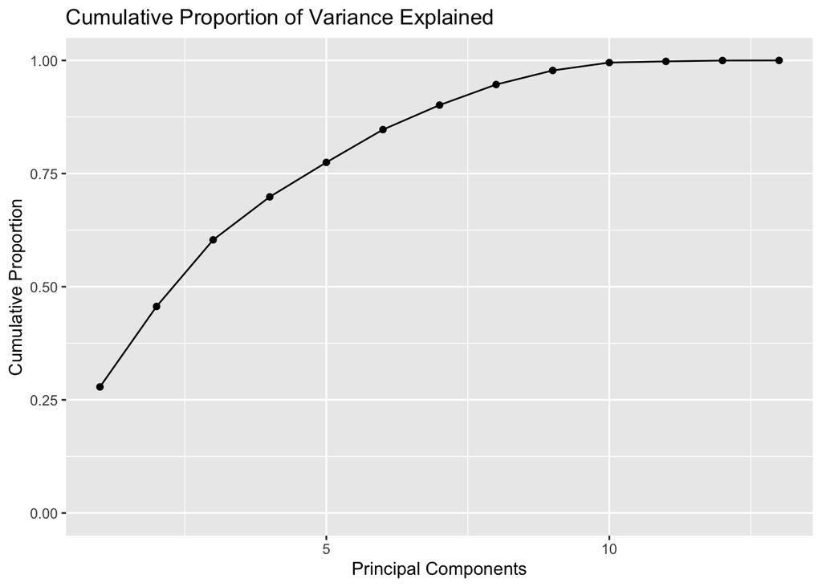

```r
#remove respond variable from trainset
trainSet2 <- trainSet %>% select(-y)

pca.out <- prcomp(trainSet2, center = TRUE, scale. = TRUE)
v <- pca.out$sdev^2 / sum(pca.out$sdev^2)
vc <- cumsum(v)
df_pca <- data.frame(PC = 1:length(vc), Variance = vc)
ggplot(df_pca, aes(x = PC, y = Variance)) +
  geom_line() +
  geom_point() +
  ylim(0, 1) +
  ggtitle("Cumulative Proportion of Variance Explained") +
  xlab("Principal Components") +
  ylab("Cumulative Proportion")
```

From the output, we can observe that the rate of increase in the cumulative proportion of variance explained slows down after Principal Components reaches 10. Thus, I will say that we will keep 10 principal components for our analysis.

#### Perform Linear Regression on the first 10 PCs

```r
pc_train <- as.data.frame(pca.out$x[, 1:10])
pc_train$ARR_DELAY <- trainSet$y
model_pca <- lm(ARR_DELAY ~ ., data = pc_train)

pc_test <- predict(pca.out, newdata = testSet[, -which(names(testSet) == "ARR_DELAY")])
pc_test <- as.data.frame(pc_test[, 1:10])

predictions <- predict(model_pca, newdata = pc_test)

mse_pca <- mean((testSet$ARR_DELAY - predictions)^2)
print(paste("The mse_pca is:", mse_pca))
```

```
## [1] "The mse_pca is: 55.5804245130693"
```

The full-set MSE stands at 42.61277, while the BSS and PCA MSEs are 42.61153 and 55.58042, respectively. The higher MSE from the PCA model, utilizing 10 principal components, indicates a suboptimal fit.

This suggests that the predictor variables’ “true” dimensionality is indeed 12. Consequently, to achieve the minimum MSE, the inclusion of the following predictor variables is recommended: DEP_TIME, DEP_DELAY, TAXI_OUT, WHEELS_OFF, WHEELS_ON, TAXI_IN, ARR_TIME, ACTUAL_ELAPSED_TIME, DISTANCE, CARRIER_DELAY, NAS_DELAY, and LATE_AIRCRAFT_DELAY.